# hw5

## Exercise 2: Deconstructing a Graphic

#### **a. Copy of the graphic**

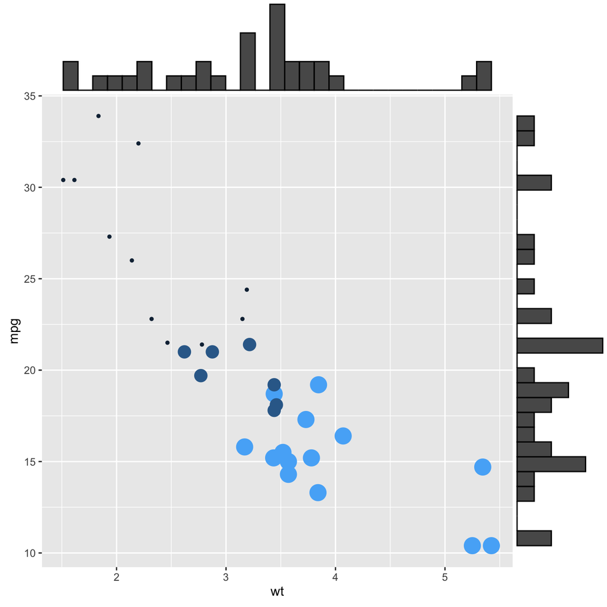

Marginal distribution added on X and Y axis of a scatter plot

[Reference: Marginal distribution with ggplot2 and ggExtra](https://r-graph-gallery.com/277-marginal-histogram-for-ggplot2.html)

#### **b. What marks are being used? What variables are mapped to which properties?**

The data they used is `mtcars`.

```r
head(mtcars)
```

```
                   mpg cyl disp  hp drat    wt  qsec vs am gear carb
Mazda RX4         21.0   6  160 110 3.90 2.620 16.46  0  1    4    4
Mazda RX4 Wag     21.0   6  160 110 3.90 2.875 17.02  0  1    4    4
Datsun 710        22.8   4  108  93 3.85 2.320 18.61  1  1    4    1
Hornet 4 Drive    21.4   6  258 110 3.08 3.215 19.44  1  0    3    1
Hornet Sportabout 18.7   8  360 175 3.15 3.440 17.02  0  0    3    2
Valiant           18.1   6  225 105 2.76 3.460 20.22  1  0    3    1
```

This graph uses two marks: points and bars.

**Points**

- x position: wt
- y position: mpg
- color: cyl
- size: cyl

**Bar**

- x position & count: wt
- y position & count: mpg

#### **c. What is the main story of this graphic?**

It shows the scatter plot of x to y as well as each x and y distributions around the scatter plot. I’m not sure what mpg and wt values represent since the website doesn’t include explanation for the data.

#### **d. What makes it a good graphic?**

It is a good graphic because it shows the same information in multiple ways: overlaying a dot plot of x vs. y and two histograms for each x and y.

#### **e. What features do you think you would know how to implement in Vega-Lite?**

It seems quite simple to make the scatter plot and histogram separately. I would have to do most of the work in `encoding`.

#### **Are there any features of the graphic that you would not know how to do in Vega-Lite? If so, list them.**

Overlaying different types of marks

## Exercise 3

#### **1 ) high temperature in Seattle each day**

```r
library(vegawidget)
'
{
  "$schema": "https://vega.github.io/schema/vega-lite/v5.json",
  "data": {
    "url": "https://calvin-data304.netlify.app/data/weather-with-dates.csv"
  },
  "height": 200,
  "width": 500,
  "mark": "line",

  "encoding": {
    "x": {
      "field": "date",
      "type": "temporal",
      "timeUnit": "monthdate",
      "title": "Month"
    },
    "y": {
      "field": "temp_max",
      "type": "quantitative",
      "title": "Mean Temperature"
    },
    "color": {"field": "year"},
    "opacity": {"value": 0.5}
  }
}' |> as_vegaspec()
```

[interactive chart not shown]

#### **2) mean temperature for each month**

The graphic should show 12 months.

My first graph: separating each year by color

```r
'{
  "$schema": "https://vega.github.io/schema/vega-lite/v5.json",
  "data": {
    "url": "https://calvin-data304.netlify.app/data/weather-with-dates.csv"
  },
  "height": 200,
  "width": 500,
  "mark": "line",
  "transform": [
  {
    "calculate": "(datum.temp_max + datum.temp_min) / 2",
    "as": "temp_mean"
  }
],
  "encoding": {
    "x": {
      "field": "date",
      "type": "temporal",
      "timeUnit": "month",
      "title": "Month"
    },
    "y": {
      "field": "temp_mean",
      "type": "quantitative",
      "aggregate": "mean",
      "title": "Mean Temperature"
    },
    "color": {"field": "year"},
    "opacity": {"value": 0.7}
  }
}' |> as_vegaspec()
```

[interactive chart not shown]

My second graph: showing the mean of all four years

```r
'{
  "$schema": "https://vega.github.io/schema/vega-lite/v5.json",
  "data": {
    "url": "https://calvin-data304.netlify.app/data/weather-with-dates.csv"
  },
  "height": 200,
  "width": 500,
  "mark": "line",
  "transform": [
  {
    "calculate": "(datum.temp_max + datum.temp_min) / 2",
    "as": "temp_mean"
  }
],
  "encoding": {
    "x": {
      "field": "date",
      "type": "temporal",
      "timeUnit": "month"
    },
    "y": {
      "field": "temp_mean",
      "type": "quantitative",
      "aggregate": "mean"
    },
    "opacity": {"value": 0.7}
  }
}' |> as_vegaspec()
```

[interactive chart not shown]